# week_6_lab

Lauren Skube

11/11/2020

## Part 1: Attach packages

## Part 2: a rank-based test example (Mann Whitney U)

- create two sample vectors
- use sample.int() to create random samples with integers 1 to x, of size =?, with replacement
- explore each vector with a histogram

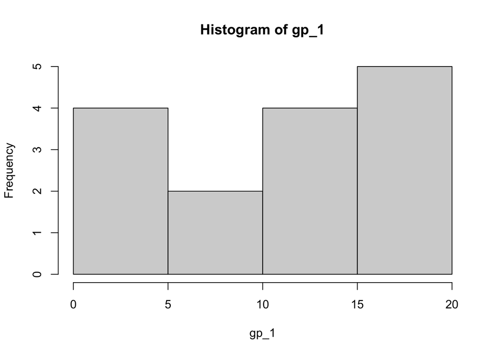

```r
set.seed(1414)
gp_1 <- sample.int(20, size = 15, replace = TRUE)

set.seed(1424)
gp_2 <- sample.int(30, size = 15, replace = TRUE)

# Exploratory histogram
hist(gp_1)
```

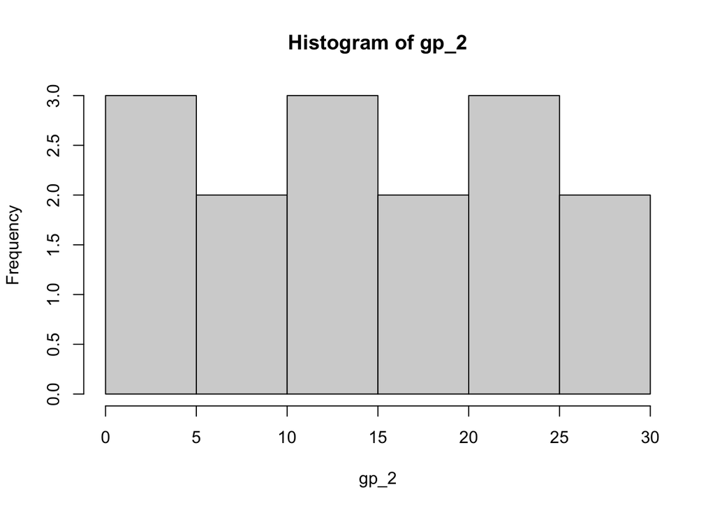

```r
hist(gp_2)
```

### Why choose a rank-based test?

1. Not clearly normally distributed from exploratory histograms
2. Somewhat small sample size (n=15)
3. I’ve decided ranks (or medians) are a more valuable metric to compare these data

## Perform Mann-Whitney U

- to answer "is there a significant difference in ranks (medians) between gp_1 and gp_2?
- using the wilcox.test() function

```r
my_mwu <- wilcox.test(gp_1, gp_2) # Call in console to view
```

### What does the p-value of 0.28 mean?

- It means that if the null hypothesis is true (these samples were drawn from populations with the same median), there is a probability of 0.28 that we could have found median values *at least as different as ours* by chance.

## Part 3: Simple linear regression

- use the penguins data set to explore the relationship between flipper length and body mass for penguins , including all 3 penguin species in the data set

### Part 3(A): Look at data

- make an exploratory scatterplot

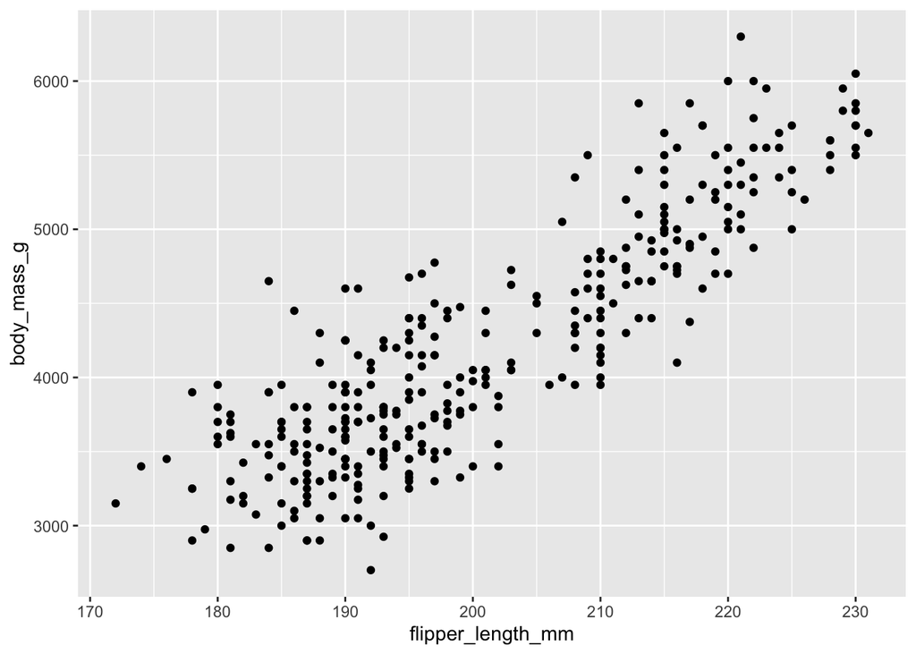

```r
ggplot(data = penguins, aes(x = flipper_length_mm, y = body_mass_g)) +
  geom_point()
```

### Questions to ask:

1. does it look like a linear relationship makes sense?
2. do we have any concerns about modeling as a linear relationship?
3. any notable outliers?
4. initial thoughts about homoscedasticity?

### Part 3(B): Model it

- using lm() function

```r
# Linear model, stored as penguin_lm
penguin_lm <- lm(body_mass_g ~ flipper_length_mm, data = penguins)

# Return the complete overview:
summary(penguin_lm)
```

```
##
## Call:
## lm(formula = body_mass_g ~ flipper_length_mm, data = penguins)
##
## Residuals:
##      Min       1Q   Median       3Q      Max
## -1058.80  -259.27   -26.88   247.33  1288.69
##
## Coefficients:
##                    Estimate Std. Error t value Pr(>|t|)
## (Intercept)       -5780.831    305.815  -18.90   <2e-16 ***
## flipper_length_mm    49.686      1.518   32.72   <2e-16 ***
## ---
## Signif. codes:  0 '***' 0.001 '**' 0.01 '*' 0.05 '.' 0.1 ' ' 1
##
## Residual standard error: 394.3 on 340 degrees of freedom
##   (2 observations deleted due to missingness)
## Multiple R-squared:  0.759,  Adjusted R-squared:  0.7583
## F-statistic:  1071 on 1 and 340 DF,  p-value: < 2.2e-16
```

The multiple R2 value is 0.759- meaning that 75.9% of variance in body mass is explained by flipper length.

### Part 3(C): Access model outputs

We can access the coefficients for the model using:

```r
# use the broom::tidy() function to get model outputs in nice data format
penguin_lm_tidy <- broom::tidy(penguin_lm)

# Look at output by calling it in the console

# Get the intercept:
penguin_int <- penguin_lm_tidy$estimate[1]
penguin_int
```

```
## [1] -5780.831
```

```r
# Get the flipper_length coefficient:
penguin_coef <- penguin_lm_tidy$estimate[2]
penguin_coef
```

```
## [1] 49.68557
```

```r
# Metrics at a glance:
penguin_lm_out <- broom::glance(penguin_lm)
penguin_lm_out
```

```
## # A tibble: 1 x 12
##   r.squared adj.r.squared sigma statistic   p.value    df logLik   AIC   BIC
##       <dbl>         <dbl> <dbl>     <dbl>     <dbl> <dbl>  <dbl> <dbl> <dbl>
## 1     0.759         0.758  394.     1071. 4.37e-107     1 -2528. 5063. 5074.
## # … with 3 more variables: deviance <dbl>, df.residual <int>, nobs <int>
```

“Simple linear regression was used to explore the relationship between penguin flipper length (mm) and body mass (g) across all three penguin species, and including both male and female penguins. A significant regression model was found (β = 49.686, F(1,340) = 1070.7, p < 0.001) with an R2 of 0.759.”

### Part 3(D): Explore model assumptions

We have assumptions for linear regression model we need to explore, some related to the residuals. - Linearly related variables (CHECK - already looked and thought hard about) - Normally distributed *residuals* - Homoscedasticity (constant residual variance) - iid residuals (no serial correlation) - more often a concern in time series data

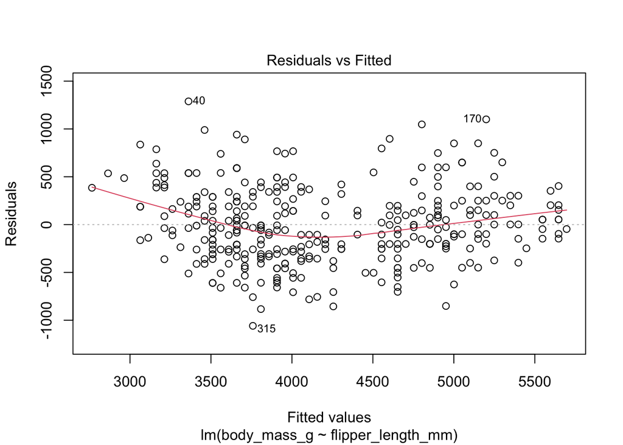

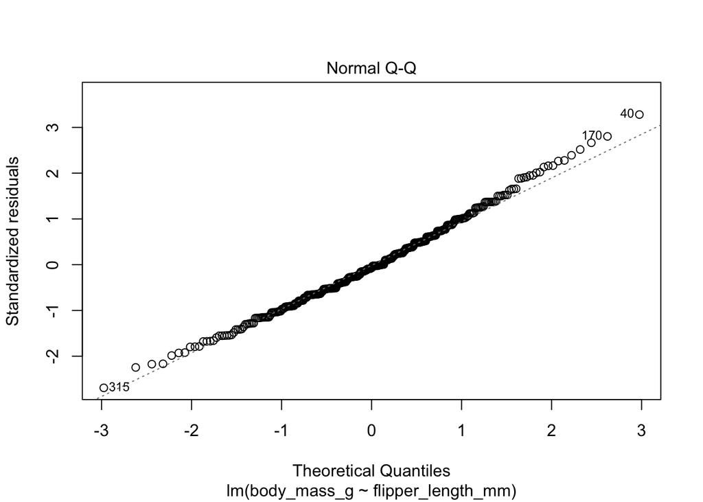

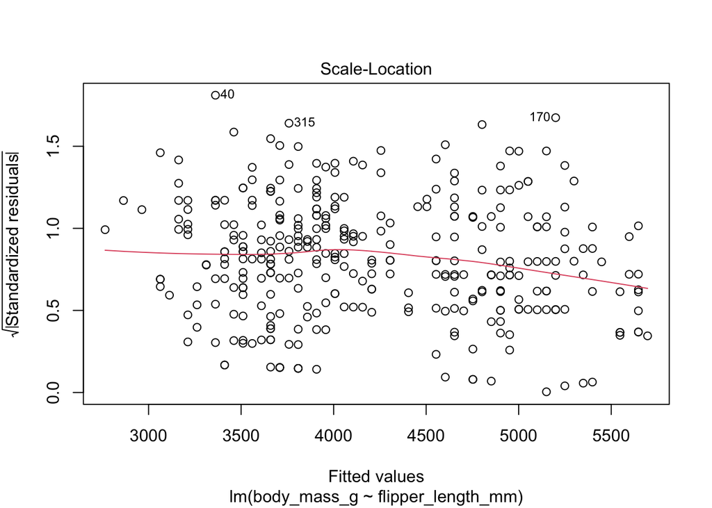

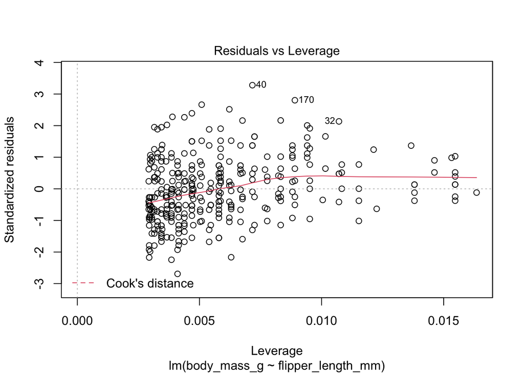

```r
# use the plot() function - will already create four useful visualizations to consider assumptions
plot(penguin_lm)
```

- graphs 1 & 3 are useful for thinking about homoscedasticity
- graph 2 (QQ plot) helps us consider normality of residuals
- graph 4 reveals Cook’s distance (a measure of how much leverage any single observation has on the model)

### E. Visualize the model

- we’ve looked at assumptions and decided linear regression is a valid tool to describe the relationship between flipper length and body mass
- now use geom_smooth() to add a linear model to an existing scatterplot
- Use stat_cor() and/or stat_regline_equation() to add equation information directly to the plot panel, at an x- and y-position that you specify

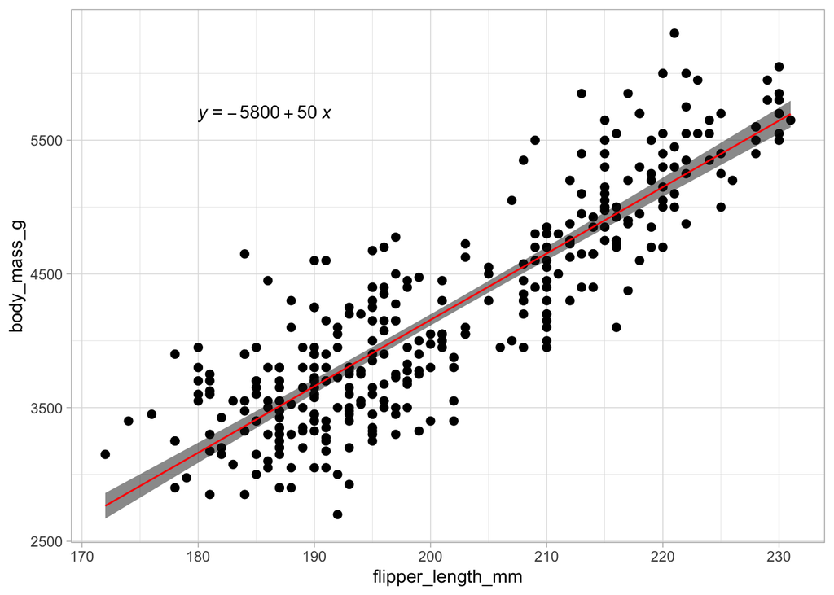

```r
ggplot(data = penguins, aes(x = flipper_length_mm, y = body_mass_g)) +
  geom_point(size = 2) +
  geom_smooth(method = "lm",
              color = "red",
              size = 0.5,
              fill = "gray10",
              alpha = 0.5) +
  theme_light() +
  ggpubr::stat_regline_equation(label.x = 180, label.y = 5700)
```

### F. Find Pearson’s r for correlation

- to tell us the strength of the correlation (degrees of relationship) between the two variables which, for two linearly related continuous variables, can be expressed using Pearson’s r
- Typical guidelines:
- r = 0, no correlation
- r < |0.3| and |0.7|: moderate correlation
- r > |0.7|: strong correlation

```r
penguins_cor <- cor.test(penguins$flipper_length_mm, penguins$body_mass_g)

penguins_cor
```

```
##
##  Pearson's product-moment correlation
##
## data:  penguins$flipper_length_mm and penguins$body_mass_g
## t = 32.722, df = 340, p-value < 2.2e-16
## alternative hypothesis: true correlation is not equal to 0
## 95 percent confidence interval:
##  0.843041 0.894599
## sample estimates:
##       cor
## 0.8712018
```

- We see that there is a strong positive correlation between flipper length and body mass (r = 0.87, t(340) = 32.72, p<0.0001)